## **Name:** Alyssa Rask

## **Computing ID:** jez2sk

# Lab 1: Pandas and Data Sourcing (50 Points)

Version 2

```python
import pandas as pd
import numpy as np
import matplotlib.pyplot as plt
import requests
from bs4 import BeautifulSoup
import re


from pydataset import data
```

## Part 1: Data Structure Review and Pandas Functions (20 Points)

## **Question 1 (10 points):** Read in or load a dataset as a Pandas DataFrame with at least 3 features and no more than 5. You may need to drop or filter columns in larger DataFrames. Make a single summary visual that encodes *all* the features (ie: columns) in your DataFrame. You may load your own dataset in (ie: from Kaggle), or pick from the datasets available in PyDataset already loaded below for your convenience.

For example, you could summarize a dataset with 3 features with a simple scatter plot and colors for different values in a column. You could also plot each column individually. Features like different line or point labels, plot types, color, marker shapes, and even subplots might be necessary!

```python
comp_450_df = pd.DataFrame(pd.read_excel("Comparison_450MHz_10000points_ROvsITM.xlsx"))
#dropping redundant and irrelavent data
comp_450_df = comp_450_df.drop(["Avg diff", "STD diff", "Frequency (MHz)", "Location", "NRQZ ID", "AGL (m)"], axis = 1)
comp_450_df
```

|  | Latitude | Longitude | TPA - itmlogic [min] | TPA - TAP RO | Difference [itmlogic - RO] | Percentage Change [itmlogic / RO] | Elevation (m) |
| --- | --- | --- | --- | --- | --- | --- | --- |
| 0 | 37.500111 | -78.499722 | 180.290025 | 199.40 | -19.109975 | 9.583739 | 179.3 |
| 1 | 37.502111 | -78.499722 | 180.728718 | 201.45 | -20.721282 | 10.286067 | 186.0 |
| 2 | 37.504111 | -78.499722 | 180.365875 | 202.76 | -22.394125 | 11.044646 | 181.1 |
| 3 | 37.506111 | -78.499722 | 180.232145 | 202.73 | -22.497855 | 11.097447 | 187.5 |
| 4 | 37.508111 | -78.499722 | 180.307816 | 202.73 | -22.422184 | 11.060121 | 180.0 |
| ... | ... | ... | ... | ... | ... | ... | ... |
| 9985 | 38.106111 | -80.453722 | 181.117588 | 199.76 | -18.642412 | 9.332405 | 1028.7 |
| 9986 | 38.108111 | -80.453722 | 185.895670 | 204.33 | -18.434330 | 9.021842 | 1012.7 |
| 9987 | 38.110111 | -80.453722 | 182.196939 | 204.90 | -22.703061 | 11.080069 | 1029.6 |
| 9988 | 38.112111 | -80.453722 | 173.385960 | 200.69 | -27.304040 | 13.605082 | 1036.6 |
| 9989 | 38.114111 | -80.453722 | 172.640717 | 194.75 | -22.109283 | 11.352648 | 1024.9 |

9990 rows × 7 columns

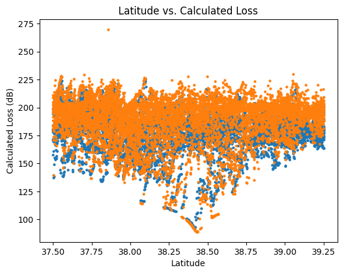

```python
#due to the nature of the data, it's not possible to sensibly graph five of these features on one graph, since the axes would have different units.
#latitude and longitude are based on geographical location, elevation is in meters, itmlogic and RO are in dB, and difference and perc. change are based on the relationship between the two

plt.scatter(x = comp_450_df["Latitude"], y = comp_450_df["TPA - itmlogic [min]"], s=5)
plt.scatter(x = comp_450_df["Latitude"], y = comp_450_df["TPA - TAP RO"], s=5)
plt.xlabel("Latitude")
plt.ylabel("Calculated Loss (dB)")
plt.title("Latitude vs. Calculated Loss")
plt.show()
```

## **Question 2 (5 points):** Use your visualization to segment the dataset into at least 3 natural groups using any form of Pandas filtering functions. Save each group's data as its own DataFrame.

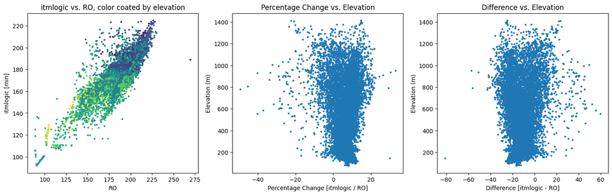

```python
fig, axs = plt.subplots(1, 3, figsize=(18,5))

axs[0].scatter(x = comp_450_df["TPA - TAP RO"], y = comp_450_df["TPA - itmlogic [min]"], s=5, c = comp_450_df["Elevation (m)"])
axs[0].set_title("itmlogic vs. RO, color coated by elevation")
axs[0].set_ylabel("itmlogic [min]")
axs[0].set_xlabel("RO")

axs[1].scatter(x = comp_450_df["Percentage Change [itmlogic / RO]"], y = comp_450_df["Elevation (m)"], s=5)
axs[1].set_title("Percentage Change vs. Elevation")
axs[1].set_xlabel("Percentage Change [itmlogic / RO]")
axs[1].set_ylabel("Elevation (m)")

axs[2].scatter(x = comp_450_df["Difference [itmlogic - RO]"], y = comp_450_df["Elevation (m)"], s=5)
axs[2].set_title("Difference vs. Elevation")
axs[2].set_xlabel("Difference [itmlogic - RO]")
axs[2].set_ylabel("Elevation (m)")

plt.show()
```

## **Question 3 (5 points):** Print a summary of each DataFrame including its size, shape, and descriptive statistics using the describe function. Write a few sentences in a text cell on if any relationships emerge and if the results are surprising or expected.

The first of these graphs shows a strong, positive coorrelation between the two models, with the RO model predicting a higher amount of loss on average at this frequency. It also seems like there is an outlier, though, given the number of points, it likely won't have a large effect on the data. Based on the color of the points, it seems like lower elevations, represented by darker colors, have a higher predicted loss, as they appear clustered mostly in the top right of the graph.

The percentage change vs. elevation graph looks to have an average of about 5-10%, though there is a lot more variation on the left of the mean than the right.

The opposite is true for the Difference vs. Elevation graph; higher differences have more variation. This graph looks to have an average of around -15dB.

## Part 2: Getting Data From APIs and Web Scraping (30 points)

A great source of data and Pandas practice is getting data from the Internet. Rather than a .csv file, many data will be in a stream of records, typically in XML (eXtensible Mark-up Language) or JSON (JavaScript Object Notation) format.

In the 2nd part of this lab, you will choose from utilizing a simple API for getting and analyzing data through a variety of queries or web scraping a page.

**Web Scraping Examples**

- Any Wikipedia page
  - https://en.wikipedia.org/wiki/Capybara
  - https://en.m.wikipedia.org/wiki/List_of_common_misconceptions
- https://toscrape.com/
- https://www.scrapethissite.com/
- https://github.com/stanfordjournalism/search-script-scrape

**API Examples**

- https://pokeapi.co/
  - Example: https://pokeapi.co/api/v2/pokemon?limit=1000&offset=0
- https://place.dog/
- https://dukengn.github.io/Dog-facts-API/
- https://apiv3.iucnredlist.org/api/v3/docs

A more exhaustive API list can be found at: https://github.com/public-apis/public-apis.

## **Question 1 (5 points):** Pick a URL (several examples are above) to either web scrape data from OR query using an API (no need to do both). Download your initial raw data using the `requests` package and store it in a variable.

## Print your variable. Observe what kind of data your API or website can produce and design a DataFrame of at least 1 column you would like to create. Write the feature(s) you plan on obtaining below.

### **URL Chosen:** https://en.wikipedia.org/wiki/Solar_System

### **API or Web Scraping:** Web Scraping

### **DataFrame Column(s):** Planet, Min Distance (AU), Max Distance (AU)

## **Question 2 (10 points):**

## Create the DataFrame of your selected feature(s). Whether using an API or scraping, you might need to implement loops to extract enough clean features to use. Be creative with using iteration and data structures to get your data!

```python
# Specify a user agent
headers = {
    'User-Agent': 'Mozilla/5.0 (Windows NT 10.0; Win64; x64) AppleWebKit/537.36 (KHTML, like Gecko) Chrome/58.0.3029.110 Safari/537.3'
}

# Define URL
url = "https://en.wikipedia.org/wiki/Solar_System"

# Fetch the webpage with user agent
response = requests.get(url, headers=headers)
soup = BeautifulSoup(response.content, 'html.parser')
```

```python
response
```

```
<Response [200]>
```

```python
# Testing to make sure it worked
headers = soup.find_all(['h2'])
for header in headers:
    print(header.text)
```

```
Contents
Formation and evolution
General characteristics
Sun
Inner Solar System
Outer Solar System
Trans-Neptunian region
Miscellaneous populations
Boundary region and uncertainties
Celestial neighborhood
Galactic position
Discovery and exploration
See also
Notes
References
External links
```

```python
# Extract all list text
list_items = soup.find_all('li')
text = " ".join([li.get_text() for li in list_items])

#choose which solar system objects to scan for
search = ["Mercury", "Venus", "Earth", "Mars", "Jupiter", "Saturn", "Uranus", "Neptune"]

# Create a regex pattern dynamically from the list of object names
search_pattern = "|".join(search)  # Join planet names with "|"
pattern = rf"({search_pattern})\s*\(([\d\.]+)\s*–\s*([\d\.]+)\s*AU"

# Find all matches
matches = re.findall(pattern, text)

# Store extracted data
data = [{"Planet": planet, "Min Distance (AU)": float(min_dist), "Max Distance (AU)": float(max_dist)} for planet, min_dist, max_dist in matches]

# Create a DataFrame
df = pd.DataFrame(data)

# Print the DataFrame
print("\nExtracted DataFrame:")
print(df)
```

```
Extracted DataFrame:
    Planet  Min Distance (AU)  Max Distance (AU)
0  Mercury               0.31               0.59
1    Venus               0.72               0.73
2    Earth               0.98               1.02
3     Mars               1.38               1.67
4  Jupiter               4.95               5.46
5   Saturn               9.08              10.12
6   Uranus              18.30              20.10
7  Neptune              29.90              30.50
```

## **Question 3 (15 points):** Perform an exploratory analysis on the DataFrame you've created, making modifications to it as necessary. Some example features to explore include:

- If you've scraped text data, plot a few rows of data
- If you've scraped any image URLs, plot a few of them
- If you've scraped any image URLs, add a column for file extension type
- Run some value counts on different variables
- If your columns are messy or hard to read, rename them
- Cast data types into a usable state (ie: string to integer for numerical analysis)

## After exploring, write down 1 to 2 sentences about any interestings aspects of your data (group characteristics, clear relationships between variables) or your process of getting it.

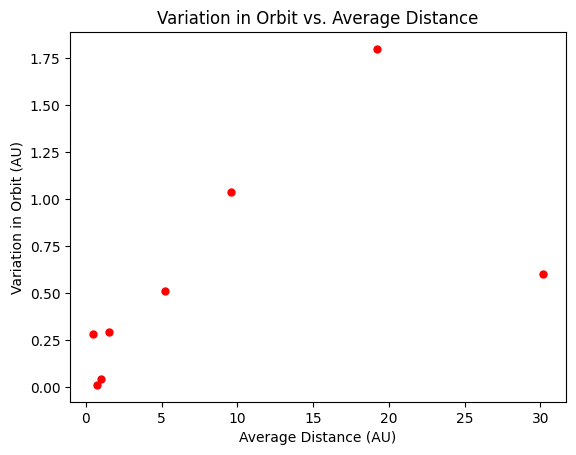

```python
# Calculate new data using scraped values
df['Average Distance (AU)'] = (df['Min Distance (AU)'] + df['Max Distance (AU)']) / 2
df['Variation in Orbit (AU)'] = (df['Max Distance (AU)'] - df['Min Distance (AU)'])

# Plot data
plt.scatter(x = df["Average Distance (AU)"], y = df["Variation in Orbit (AU)"], s = 25, c = "red")
plt.xlabel("Average Distance (AU)")
plt.ylabel("Variation in Orbit (AU)")
plt.title("Variation in Orbit vs. Average Distance")
plt.show()
```

From the distrbution of data, we can see that planets closer to the Sun are less spread out, while those past the asteroid belt, the outer planets, are significantly more spread out. Beyond that, we can also see that distance from the Sun may have an effect on the ecentricity of a planet's orbit—the inner planets have less variation in their orbits than the outer ones. There is not enough data to come to confidently conclude that there is a correlation between the two, but we can see that there is the beginnings of such a pattern within our own solar system.

### Honor Pledge

On my honor as a student, I have neither given nor received unauthorized aid on this assignment.